# BayesBinMix Census Data Results Summarized

Author

Carmen B. Rodriguez

```r
#Load packages
library(tidyverse)
library(Hmisc)
library(reshape2)
library(ggplot2)
library(psych)
library(table1)
library(tableone)
library(Hmisc)
library(BayesBinMix)
library(foreach)
library(label.switching)
library(doParallel)
library(coda)
library(DescTools)
library(MCMCvis)
library(knitr)
library(forcats)
```

```r
#Load census data
censusdata_bin <- readRDS("./censusdata_bin.rds")
names(censusdata_bin) <- c("acs5_2010_bin","acs5_2015_bin","acs5_2019_bin")
```

The Multivariate Bernoulli Mixture Model

The dimensionality of the multivariate distribution is equal to $d = 14$.

The following prior assumptions are imposed

$$K \sim \text{Truncated Poisson}(\lambda = 1)$$

$$p|K \sim \text{Dirichlet}(1,..., 1_K)$$
We set $\gamma_1=...= \gamma_K =\gamma > 0$ so that prior assumptions do not impose any particular information that separates the mixture components between them.

$$\theta_{kj} \sim \text{Beta}(\alpha=1, \beta=1)$$

## Run models

We will run models with different values of $K_{max}$ . That is, we will look at output where the upper bound on $K$ is `K= c(5,10,15)` .

**A few notes:**

- We only show patterns for ACS 2006-2010 and ACS 2011-2015 when $K_{max} = 10$, resulting in a most probable model (henceforth refered as mapK) of mapK = 4.
- Tried to add labels/descriptions to each cluster based on success probabilities of the included neighborhood SES variables.

```r
#Load model results--will be stored in GitHub
res_acs10<- readRDS("./ACS10_results.rds")
res_acs10_10<-res_acs10[[3]]
#res_acs10_15<-res_acs10[[5]]
```

```r
res_all <- readRDS("./ACS15_19_results.rds")

#ACS 2015
res_acs15_10<-res_all$res_acs15_10
#res_acs15_15<-res_all$res_acs15_15

Mode(res_acs15_10$K.mcmc)[1]
#Mode(res_acs15_15$K.mcmc)[1]
```

```r
#ACS 2019
res_acs19_10<-res_all$res_acs19_10
#res_acs19_15<-res_all$res_acs19_15

Mode(res_acs19_10$K.mcmc)[1]
#Mode(res_acs19_15$K.mcmc)[1]
```

### **Plots** (Patterns for ACS 2006-2010)

```r
#Import functions from plots.R
source("plots.R")
library(viridis)
sesvars<-c("Two People Per Room","Lack of complete Plumbing", "Median Household Income", ">= Bacherlor's Degree", "Below Poverty Line", "< High School",
           "Female Household", ">= High School","No Vehicle","Owner", "Renter", "Unemployment","White Collar Occupation", "SNAP Benefits")


# Other color options
viridis_palette <- viridis(14)
custom_colors <- c("#1f77b4", "#ff7f0e", "#2ca02c", "#d62728", "#9467bd",
                   "#8c564b", "#e377c2", "#7f7f7f", "#bcbd22", "#17becf",
                   "#ff0000", "#00ff00", "#0000ff", "#ffff00")

group_cols<-c("#1f77b4","#2ca02c","salmon1", "#bcbd22")


# Generate 14 pastel colors for ungrouped graph
pastel_palette1 <- generate_pastel_colors(14)
```

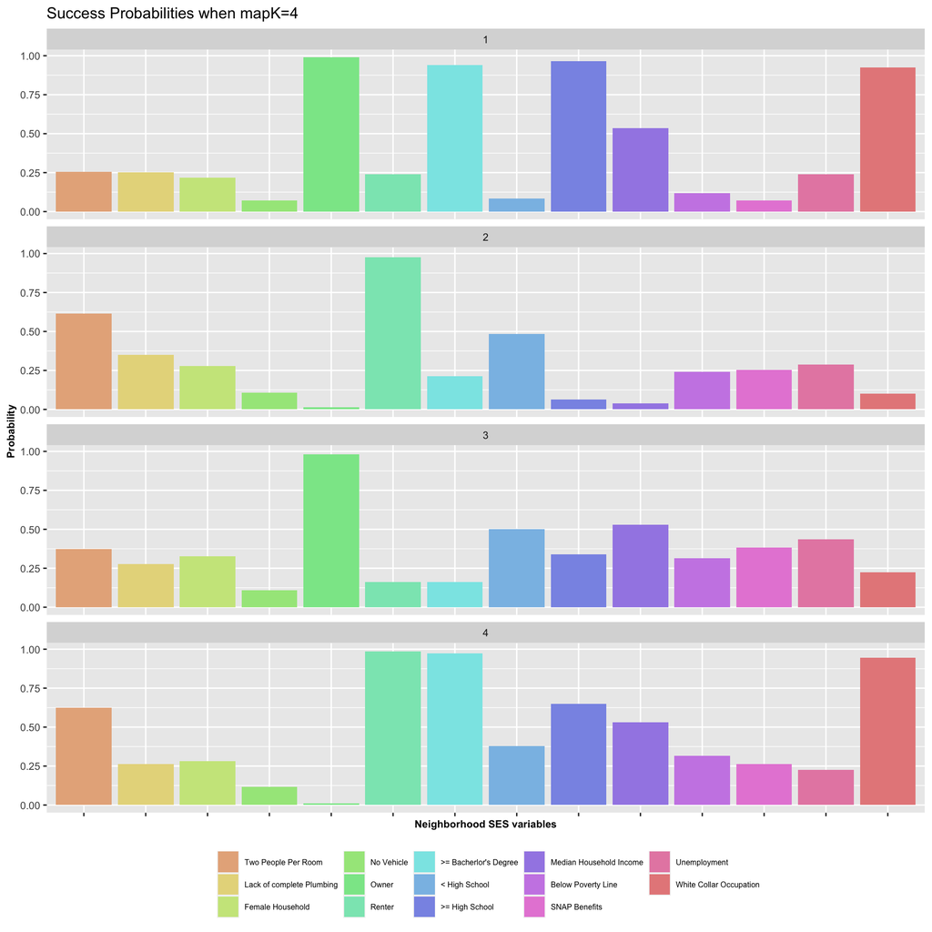

Individual Neighborhood SES variables

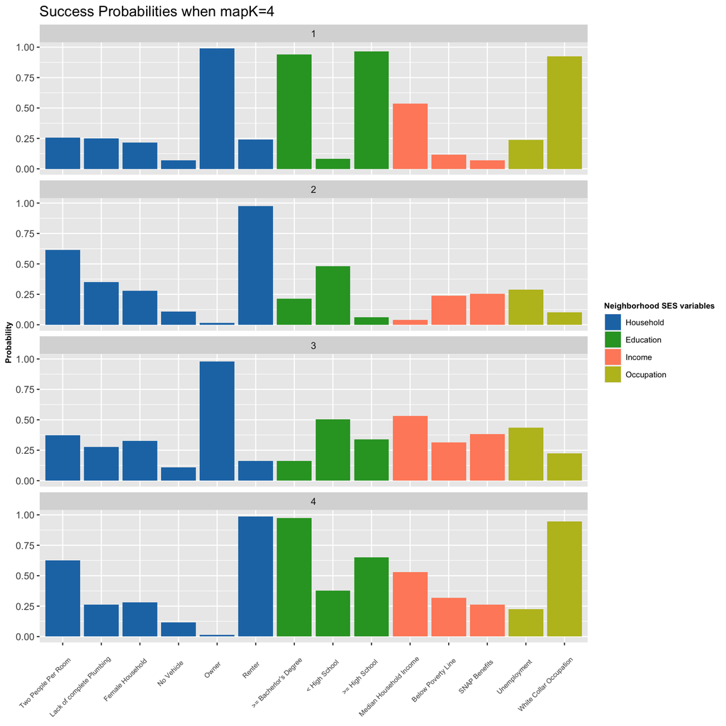

Grouped Neighborhood SES variables

```r
#Kmax = 10
mapK<-Mode(res_acs10_10$K.mcmc)[1]  #tells you mapK
fig_title = paste("Success Probabilities when mapK=", mapK, sep="")
dat_10<-preparedat_fig(res_acs10_10,mapK,sesvars)
p_10_indiv<-plot_thetakj_indiv(prob_est_long = dat_10, mapK,color_palette = pastel_palette1, fig_title)
#p_10_group1<-plot_thetakj_group1(prob_est_long = dat_10, mapK,color_palette = group_cols, fig_title)
p_10_group<-plot_thetakj_group(prob_est_long = dat_10, mapK,color_palette = group_cols, fig_title)

p_10_indiv
p_10_group
#p_10_group1


#to describe patterns
#dat_10 %>% group_by(cluster) %>% arrange(theta_kj,.by_group = T)
```

#### Observed patterns description -- to be discussed with Briana and Stephanie

- **Cluster 1 :** This cluster has higher success probabilities for SES variables like: higher education level, home ownership, white-collar occupations, and higher median income.
  - *Summarize this as possibly the “High SES” category.*
- **Cluster 2:** Higher success probabilities for households with 2 or more occupants per room, < HS education, renters, no complete plumbing and unemployment.
  - *Summarize this as possibly the “Med-Low SES” category.*
- **Cluster 3:** Higher success probabilities for < HS education, SNAP benefits, female households, household owners, unemployment.
  - *Summarize this as possibly the “Low SES” category.*
- **Cluster 4:** Higher success probabilities for renters, higher education, white collar occupation, low success probability for unemployment, SNAP benefits and female household.
  - *Summarize this as possibly the “Medium SES” category.*

#### **Cluster weights:**

```r
#Class probabilities
stats<-cbind(summary(res_acs10_10$parameters.ecr.mcmc)$statistics[,c(1,2)], summary(res_acs10_10$parameters.ecr.mcmc)$quantiles[,c(1,5)])

tail(stats, mapK) %>% kable()
```

|  | Mean | SD | 2.5% | 97.5% |
| --- | --- | --- | --- | --- |
| p.1 | 0.2926309 | 0.0146359 | 0.2660806 | 0.3190379 |
| p.2 | 0.3252673 | 0.0151914 | 0.2976844 | 0.3530280 |
| p.3 | 0.2129842 | 0.0142114 | 0.1863169 | 0.2423785 |
| p.4 | 0.1691176 | 0.0147839 | 0.1465226 | 0.1917268 |

```r
#Kmax = 15
mapK<-Mode(res_acs10_15$K.mcmc)[1]  #tells you mapK
fig_title = paste("Success Probabilities when mapK=", mapK, sep="")
dat_15<-preparedat_fig(res_acs10_15,mapK,sesvars)
p_15_indiv<-plot_thetakj_indiv(prob_est_long = dat_15, mapK,color_palette = pastel_palette1, fig_title)
p_15_group<-plot_thetakj_group(prob_est_long = dat_15, mapK,color_palette = group_cols, fig_title)
p_15_indiv
p_15_group
```

```r
#Class probabilities
stats<-cbind(summary(res_acs10_15$parameters.ecr.mcmc)$statistics[,c(1,2)], summary(res_acs10_15$parameters.ecr.mcmc)$quantiles[,c(1,5)])

tail(stats, mapK) %>% kable()
```

### **Plots** (Patterns for ACS 2011-2015)

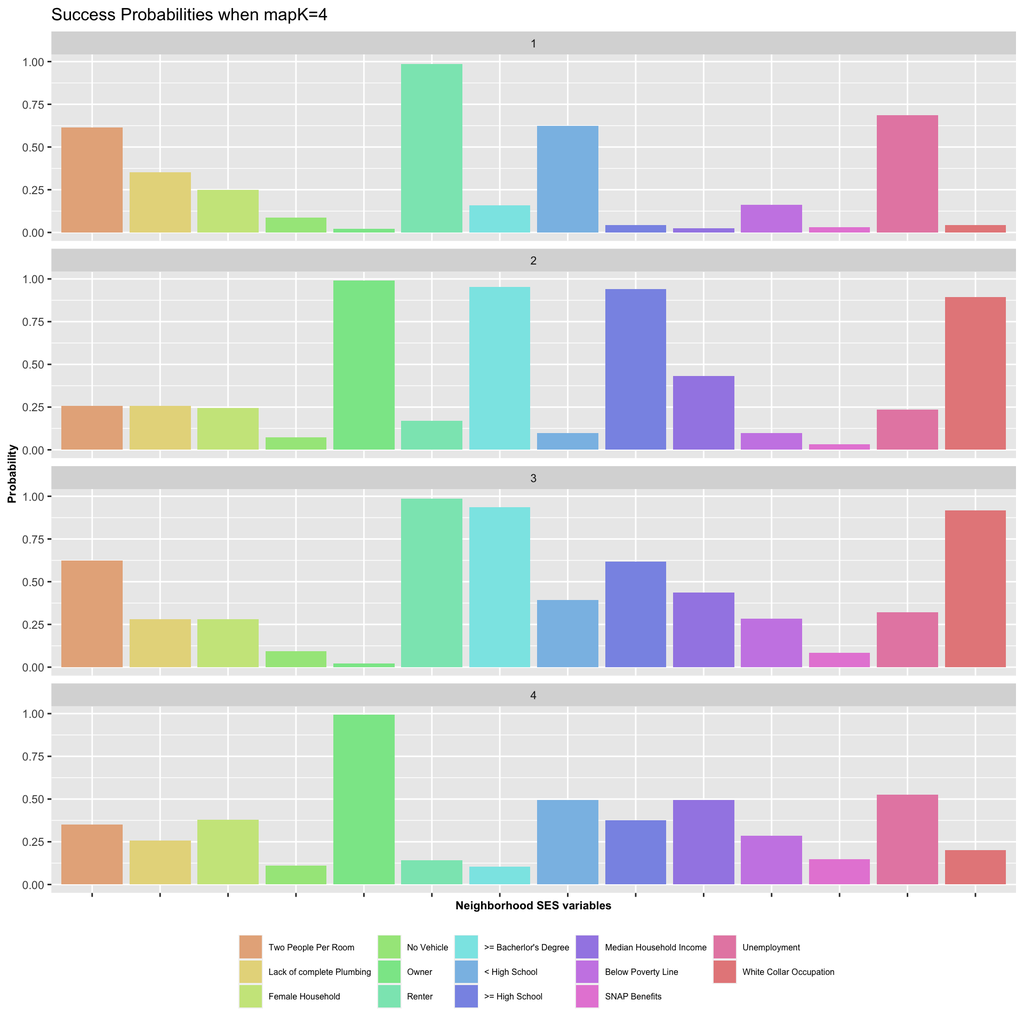

Individual Neighborhood SES variables

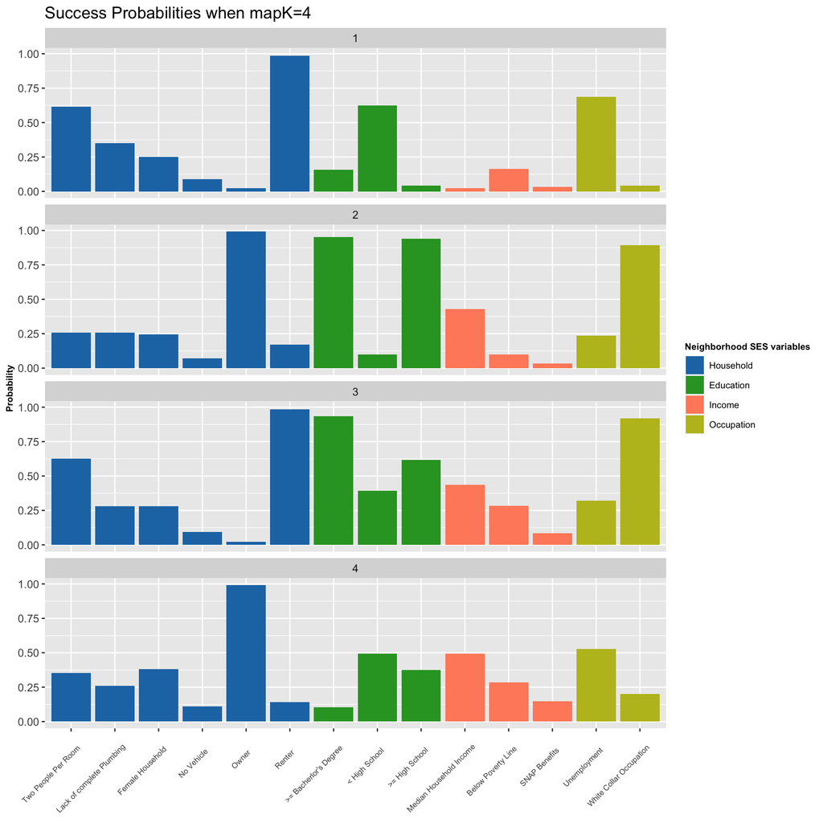

Grouped Neighborhood SES variables

```r
#Kmax = 10
mapK<-Mode(res_acs15_10$K.mcmc)[1]  #tells you mapK
fig_title = paste("Success Probabilities when mapK=", mapK, sep="")
dat_15<-preparedat_fig(res_acs15_10,mapK,sesvars)
p_15_indiv<-plot_thetakj_indiv(prob_est_long = dat_15, mapK,color_palette = pastel_palette1, fig_title)
p_15_group<-plot_thetakj_group(prob_est_long = dat_15, mapK,color_palette = group_cols, fig_title)

p_15_indiv
p_15_group
#to describe patterns
#dat_15 %>% group_by(cluster) %>% arrange(theta_kj,.by_group = T)
```

#### Observed patterns description -- to be discussed with Briana and Stephanie

- **Cluster 1 :** Higher success probabilities for households with 2 or more occupants per room, < HS education, renters, and unemployment.
  - *Summarize this as possibly the ” Medium low SES” category.*
- **Cluster 2:** Higher success probabilities for high education, home ownership, white collar occupation
  - *Summarize this as possibly the “High SES” category*
- **Cluster 3:** Higher success probabilities for education , renter, white collar occupation, and households with 2 or more occupants per room.
  - *Summarize this as possibly the ” Medium SES” category.*
- **Cluster 4:** Higher success probabilities for owners, unemployment, lower educational levels, female household.
  - *Summarize this as possibly the “Low SES” category.*

#### **Cluster weights:**

```r
#Class probabilities
stats<-cbind(summary(res_acs15_10$parameters.ecr.mcmc)$statistics[,c(1,2)], summary(res_acs15_10$parameters.ecr.mcmc)$quantiles[,c(1,5)])

tail(stats, mapK) %>% kable()
```

|  | Mean | SD | 2.5% | 97.5% |
| --- | --- | --- | --- | --- |
| p.1 | 0.2955889 | 0.0135465 | 0.2710190 | 0.3225315 |
| p.2 | 0.2960474 | 0.0157876 | 0.2666307 | 0.3253265 |
| p.3 | 0.2044902 | 0.0123623 | 0.1832994 | 0.2320340 |
| p.4 | 0.2038735 | 0.0154116 | 0.1771581 | 0.2334785 |

```r
#Kmax = 15
mapK<-Mode(res_acs15_15$K.mcmc)[1]  #tells you mapK
fig_title = paste("Success Probabilities when mapK=", mapK, sep="")
dat_15<-preparedat_fig(res_acs15_15,mapK,sesvars)
p_15_indiv<-plot_thetakj_indiv(prob_est_long = dat_15, mapK,color_palette = pastel_palette1, fig_title)
p_15_group<-plot_thetakj_group(prob_est_long = dat_15, mapK,color_palette = group_cols, fig_title)
p_15_indiv
p_15_group
```

```r
#Class probabilities
stats<-cbind(summary(res_acs15_15$parameters.ecr.mcmc)$statistics[,c(1,2)], summary(res_acs15_15$parameters.ecr.mcmc)$quantiles[,c(1,5)])

tail(stats, mapK) %>% kable()
```

### How deterministic is the model?

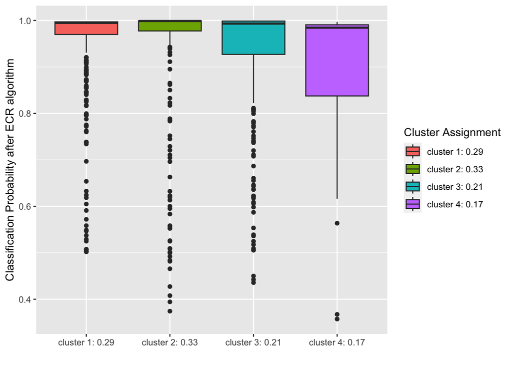

```r
mapK<-Mode(res_acs10_10$K.mcmc)[1]  #tells you mapK
#For ACS 2010 and mapK = 4
classificationprobs_10<-res_acs10_10$classificationProbabilities.ecr
# Add cluster classification based on maximum probability
maxProb<-apply(classificationprobs_10, 1, max)
ClusterAssignment<-res_acs10_10$clusterMembershipPerMethod[,2]

classificationprobs_10$ClusterAssignment<-ClusterAssignment
classificationprobs_10$maxProb<-maxProb

#Class probabilities
# stats<-cbind(summary(res_acs10_10$parameters.ecr.mcmc)$statistics[,c(1,2)], summary(res_acs10_10$parameters.ecr.mcmc)$quantiles[,c(1,5)])
# tail(stats, mapK) %>% kable()


#Prep Data for boxplot
classificationprobs_10$CT<-row.names(classificationprobs_10) #I will add actual tracts later

classificationprobs_10$ClusterAssignment<- factor(classificationprobs_10$ClusterAssignment, levels = 1:4, labels = c("cluster 1: 0.29", "cluster 2: 0.33", "cluster 3: 0.21", "cluster 4: 0.17"))

#classificationprobs_10_l<-classificationprobs_10 %>% pivot_longer(cols =1:4,names_to = "Cluster", values_to = "Probability")

datplot<- classificationprobs_10 %>% select(CT,ClusterAssignment, maxProb)


datplot%>%  ggplot(aes(x = ClusterAssignment, y = maxProb, fill = ClusterAssignment)) +
  geom_boxplot() +
  labs(fill = "Cluster Assignment", y = "Classification Probability after ECR algorithm", x= "")
```

```r
dattable<-datplot %>% rename(`Average Assignment Probability (ECR Algorithm)` = maxProb,
                    `Cluster Assignment` = ClusterAssignment)

table1::table1(~`Average Assignment Probability (ECR Algorithm)` |`Cluster Assignment`, data= dattable, overall = F)
```

|  | cluster 1: 0.29 (N=434) | cluster 2: 0.33 (N=478) | cluster 3: 0.21 (N=310) | cluster 4: 0.17 (N=256) |
| --- | --- | --- | --- | --- |
| Average Assignment Probability (ECR Algorithm) |  |  |  |  |
| Mean (SD) | 0.951 (0.100) | 0.957 (0.115) | 0.928 (0.126) | 0.920 (0.117) |
| Median [Min, Max] | 0.995 [0.502, 0.998] | 0.999 [0.374, 1.00] | 0.993 [0.436, 1.00] | 0.984 [0.357, 0.997] |

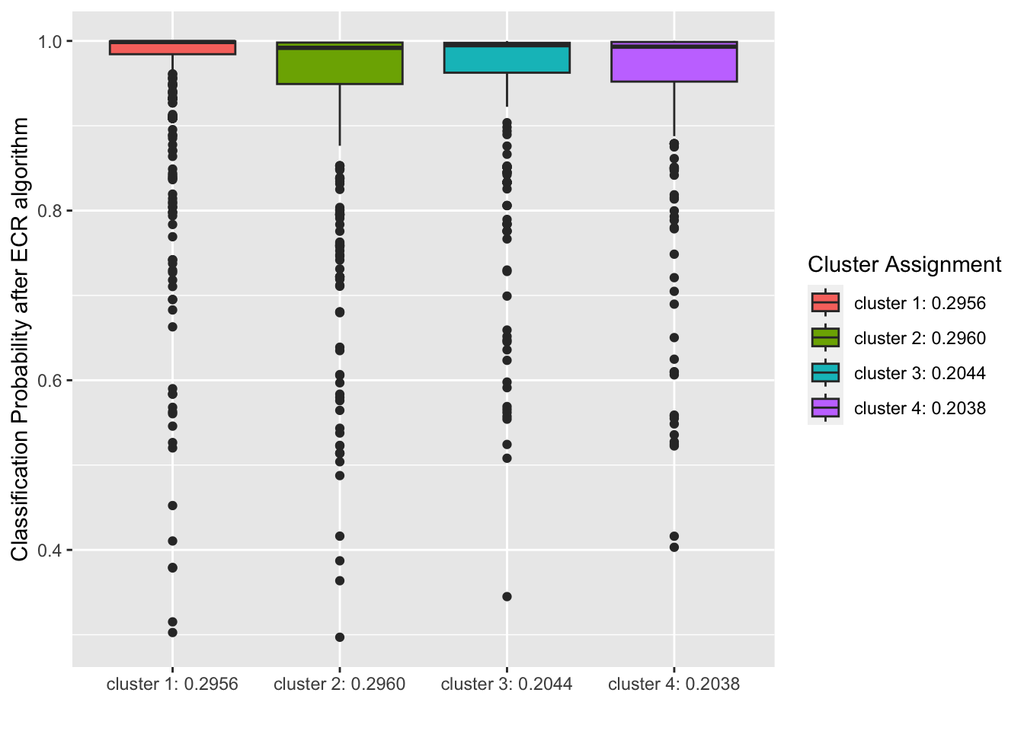

```r
#For ACS 2015 and mapK = 4
classificationprobs_15<-res_acs15_10$classificationProbabilities.ecr
classificationprobs_15$CT<-row.names(classificationprobs_15)


# stats<-cbind(summary(res_acs15_10$parameters.ecr.mcmc)$statistics[,c(1,2)], summary(res_acs15_10$parameters.ecr.mcmc)$quantiles[,c(1,5)])
#
# tail(stats, mapK) %>% kable()


colnames(classificationprobs_15)<-c("cluster 1: 0.2956", "cluster 2: 0.2960", "cluster 3: 0.2044", "cluster 4: 0.2038", "CT")



#For ACS 2015 and mapK = 4
classificationprobs_15<-res_acs15_10$classificationProbabilities.ecr
# Add cluster classification based on maximum probability
maxProb<-apply(classificationprobs_15, 1, max)
ClusterAssignment<-res_acs15_10$clusterMembershipPerMethod[,2]

classificationprobs_15$ClusterAssignment<-ClusterAssignment
classificationprobs_15$maxProb<-maxProb

#Class probabilities
# stats<-cbind(summary(res_acs10_10$parameters.ecr.mcmc)$statistics[,c(1,2)], summary(res_acs10_10$parameters.ecr.mcmc)$quantiles[,c(1,5)])
# tail(stats, mapK) %>% kable()


#Prep Data for boxplot
classificationprobs_15$CT<-row.names(classificationprobs_15) #I will add actual tracts later

classificationprobs_15$ClusterAssignment<- factor(classificationprobs_15$ClusterAssignment, levels = 1:4, labels = c("cluster 1: 0.2956", "cluster 2: 0.2960", "cluster 3: 0.2044", "cluster 4: 0.2038"))

datplot15<- classificationprobs_15 %>% select(CT,ClusterAssignment, maxProb)


datplot15%>%  ggplot(aes(x = ClusterAssignment, y = maxProb, fill = ClusterAssignment)) +
  geom_boxplot() +
  labs(fill = "Cluster Assignment", y = "Classification Probability after ECR algorithm", x= "")
```

```r
dattable15<-datplot15 %>% rename(`Average Assignment Probability (ECR Algorithm)` = maxProb,
                    `Cluster Assignment` = ClusterAssignment)

table1::table1(~`Average Assignment Probability (ECR Algorithm)` |`Cluster Assignment`, data= dattable15, overall = F)
```

|  | cluster 1: 0.2956 (N=440) | cluster 2: 0.2960 (N=449) | cluster 3: 0.2044 (N=300) | cluster 4: 0.2038 (N=289) |
| --- | --- | --- | --- | --- |
| Average Assignment Probability (ECR Algorithm) |  |  |  |  |
| Mean (SD) | 0.958 (0.108) | 0.938 (0.119) | 0.946 (0.107) | 0.945 (0.109) |
| Median [Min, Max] | 0.999 [0.303, 1.00] | 0.992 [0.297, 0.999] | 0.995 [0.345, 1.00] | 0.993 [0.403, 1.00] |

### Concordance-discordance table

Through this assessment we can get an idea of cluster mobility or how census tracts changed over time.

```r
#For this we will look at the output for clusterMembershipPerMethod
ACS10_clusters<-res_acs10_10$clusterMembershipPerMethod$ECR
ACS15_clusters<-res_acs15_10$clusterMembershipPerMethod$ECR

table(ACS10_clusters, ACS15_clusters)
```

```
              ACS15_clusters
ACS10_clusters   1   2   3   4
             1   1 365  22  46
             2 390  11  54  23
             3  29  53  12 216
             4  20  20 212   4
```

```r
prop.table(table(ACS10_clusters, ACS15_clusters) )
```

```
              ACS15_clusters
ACS10_clusters          1          2          3          4
             1 0.00067659 0.24695535 0.01488498 0.03112314
             2 0.26387009 0.00744249 0.03653586 0.01556157
             3 0.01962111 0.03585927 0.00811908 0.14614344
             4 0.01353180 0.01353180 0.14343708 0.00270636
```

```r
library(gmodels)
CrossTable(ACS10_clusters, ACS15_clusters, expected = F, prop.r = F)
```

```
   Cell Contents
|-------------------------|
|                       N |
| Chi-square contribution |
|           N / Col Total |
|         N / Table Total |
|-------------------------|


Total Observations in Table:  1478


               | ACS15_clusters
ACS10_clusters |         1 |         2 |         3 |         4 | Row Total |
---------------|-----------|-----------|-----------|-----------|-----------|
             1 |         1 |       365 |        22 |        46 |       434 |
               |   127.209 |   412.316 |    49.586 |    17.797 |           |
               |     0.002 |     0.813 |     0.073 |     0.159 |           |
               |     0.001 |     0.247 |     0.015 |     0.031 |           |
---------------|-----------|-----------|-----------|-----------|-----------|
             2 |       390 |        11 |        54 |        23 |       478 |
               |   431.166 |   124.044 |    19.078 |    53.125 |           |
               |     0.886 |     0.024 |     0.180 |     0.080 |           |
               |     0.264 |     0.007 |     0.037 |     0.016 |           |
---------------|-----------|-----------|-----------|-----------|-----------|
             3 |        29 |        53 |        12 |       216 |       310 |
               |    43.400 |    18.002 |    41.211 |   398.317 |           |
               |     0.066 |     0.118 |     0.040 |     0.747 |           |
               |     0.020 |     0.036 |     0.008 |     0.146 |           |
---------------|-----------|-----------|-----------|-----------|-----------|
             4 |        20 |        20 |       212 |         4 |       256 |
               |    41.460 |    42.913 |   492.900 |    42.376 |           |
               |     0.045 |     0.045 |     0.707 |     0.014 |           |
               |     0.014 |     0.014 |     0.143 |     0.003 |           |
---------------|-----------|-----------|-----------|-----------|-----------|
  Column Total |       440 |       449 |       300 |       289 |      1478 |
               |     0.298 |     0.304 |     0.203 |     0.196 |           |
---------------|-----------|-----------|-----------|-----------|-----------|
```

To further understand these shifts we will need to look at the cluster labels or definitions. From the pattern descriptions above we have the following:

- High -> High: 365
- Low -> Low: 216
- Med -> Med: 212
- Med-Low -> Med-Low: 390

**This gives a total of 1183/1478 concordant classification.**